# **Introduction**

> Are you a student at the University of Maryland? If so, do you live on-campus? Or are you a commuter with a dining plan?

> Well, if you've said yes to those questions, then you most likely eat at the college's dining halls pretty regularly. And, at least once, you've probably walked in thinking you'll eat healthy today, but not knowing what is "healthy" or what types of food you should eat to achieve your goal, you end up getting a bunch of random junk that, is more likely than not, horrible for you. I know I have, many, many times...

> Well, I've had it. And so should you!! We should be mindful of what we put into our bodies. That is why I decided to scrape UMD's nutrition facts, and using this data find the best, and worst foods for our bodies. We can also make a conclusion on the nutrition facts of Breakfast vs Lunch vs Dinner, to see what should be the 'biggest meal of the day' as a University of Maryland student.

```python
from bs4 import BeautifulSoup
import requests
import pandas as pd
import re
```

# **Web Scraping**

> UMD doesn't have an API or publically available CSVs containing their nutrition facts, but what they do have is a website where they post the nutrition facts of each individual item.

> So, we will have to do it ourselves!

```python
def getLinks(URL):

    menu = requests.get(URL)
    soup = BeautifulSoup(menu.content, "html.parser")
    links = []

    i = 0
    for a_href in soup.find_all("a", href=True):
        if i > 8:
            links.append("https://nutrition.umd.edu/" + a_href["href"])
        i+=1
    del(i)

    links.pop()
    return links
```

> First, I start off by getting a list of links to every food item on the website. That way, we can work on getting the specific nutrition facts.

```python
def scraper(links):
    df = pd.DataFrame(columns = ['Category', 'Serving Size','Calories (kcal)', 'Protein (g)', 'Total Fats (g)', 'Saturated Fat (g)', 'Trans Fat (g)', 'Total Carbs (g)', 'Total Sugars (g)', 'Dietary Fiber (g)', 'Sodium (mg)', 'Cholesterol (mg)'])
    h = []
    for link in links:

        label = requests.get(link)
        soup = BeautifulSoup(label.text, 'html')
        html = str(soup)


        name = re.search("<div class=\"labelrecipe\">(.*?)</div>", html)

        if name is None:
            continue;
        name = name.group(1)

        s = re.findall("<div class=\"nutfactsservsize\">(.*?)</div>", html)
        servings = s[1] if 0 <= 1 < len(s) else None
        # if s[1] is not None:

        #     servings = re.search("<div class=\"nutfactsservsize\">(.*?)</div>", s[1]).group(1)
            # lst = re.findall(r"[-+]?\d*\.\d+|\d+", servings)
            # if lst:
            #     servings = float(lst[0])
            # else:
            #     servings = 0

        calories = re.search("Calories(.*?)</span>", html)
        if calories is not None:
            calories = calories.group(1)
            lst = re.findall(r"[-+]?\d*\.\d+|\d+", calories)
            if lst:
                calories = float(lst[0])
            else:
                calories = 0

        protein = re.search("Protein(.*?)</span>", html)
        if protein is not None:
            protein = protein.group(1)
            lst = re.findall(r"[-+]?\d*\.\d+|\d+", protein)
            if lst:
                protein = float(lst[0])
            else:
                protein = 0

        total_fats = re.search("Total Fat(.*?)</span>", html)
        if total_fats is not None:
            total_fats = total_fats.group(1)
            lst = re.findall(r"[-+]?\d*\.\d+|\d+", total_fats)
            if lst:
                total_fats = float(lst[0])
            else:
                total_fats = 0

        saturated_fat = re.search("Saturated Fat.(.*?)</span>", html)
        if saturated_fat is not None:
            saturated_fat = saturated_fat.group(1)
            lst = re.findall(r"[-+]?\d*\.\d+|\d+", saturated_fat)
            if lst:
                saturated_fat = float(lst[0])
            else:
                saturated_fat = 0

        trans_fat = re.search("Trans Fat(.*?)</span>", html)
        if trans_fat is not None:
            trans_fat = trans_fat.group(1)
            lst = re.findall(r"[-+]?\d*\.\d+|\d+", trans_fat)
            if lst:
                trans_fat = float(lst[0])
            else:
                trans_fat = 0

        total_carb = re.search("Total Carbohydrate.(.*?)</span>", html)
        if total_carb is not None:
            total_carb = total_carb.group(1)
            lst = re.findall(r"[-+]?\d*\.\d+|\d+", total_carb)
            if lst:
                total_carb = float(lst[0])
            else:
                total_carb = 0

        sodium = re.search("Sodium(.*?)</span>", html)
        if sodium is not None:
            sodium = sodium.group(1)
            lst = re.findall(r"[-+]?\d*\.\d+|\d+", sodium)
            if lst:
                sodium = float(lst[0])
            else:
                sodium = 0

        cholesterol = re.search("Cholesterol(.*?)</span>", html)
        if cholesterol is not None:
            cholesterol = cholesterol.group(1)
            lst = re.findall(r"[-+]?\d*\.\d+|\d+", cholesterol)
            if lst:
                cholesterol = float(lst[0])
            else:
                cholesterol = 0

        fiber = re.search("Dietary Fiber(.*?)</span>", html)
        if fiber is not None:
            fiber = fiber.group(1)
            lst = re.findall(r"[-+]?\d*\.\d+|\d+", fiber)
            if lst:
                fiber = float(lst[0])
            else:
                fiber = 0

        sugar = re.search("Total Sugars(.*?)</span>", html)
        if sugar is not None:
            sugar = sugar.group(1)
            lst = re.findall(r"[-+]?\d*\.\d+|\d+", sugar)
            if lst:
                sugar = float(lst[0])
            else:
                sugar = 0

        food = pd.Series({'Serving Size': servings, 'Calories (kcal)': calories, 'Protein (g)': protein, 'Total Fats (g)': total_fats, 'Saturated Fat (g)': saturated_fat, 'Trans Fat (g)': trans_fat, 'Total Carbs (g)': total_carb, 'Total Sugars (g)': sugar, 'Dietary Fiber (g)': fiber, 'Sodium (mg)': sodium, 'Cholesterol (mg)': cholesterol}, name = name)

        df = df.append(food)
        #h.append(html)
    return df
```

> Here, we go into each item and take all the data we can get!

```python
dinner = "https://nutrition.umd.edu/longmenu.aspx?sName=%3cfont+style%3d%22color%3aRed%22%3eDining+%40+Maryland%3c%2ffont%3e&locationNum=16&locationName=%3cfont+style%3d%22color%3aRed%22%3eSouth+Campus%3c%2ffont%3e&naFlag=1&WeeksMenus=This+Week%27s+Menus&dtdate=12%2f20%2f2021&mealName=Dinner"
dinnerLinks = getLinks(dinner)
```

```python
lunch = "https://nutrition.umd.edu/longmenu.aspx?sName=%3cfont+style%3d%22color%3aRed%22%3eDining+%40+Maryland%3c%2ffont%3e&locationNum=16&locationName=%3cfont+style%3d%22color%3aRed%22%3eSouth+Campus%3c%2ffont%3e&naFlag=1&WeeksMenus=This+Week%27s+Menus&dtdate=12%2f20%2f2021&mealName=Lunch"
lunchLinks = getLinks(lunch)
```

```python
breakfast = "https://nutrition.umd.edu/longmenu.aspx?sName=%3cfont+style%3d%22color%3aRed%22%3eDining+%40+Maryland%3c%2ffont%3e&locationNum=16&locationName=%3cfont+style%3d%22color%3aRed%22%3eSouth+Campus%3c%2ffont%3e&naFlag=1&WeeksMenus=This+Week%27s+Menus&dtdate=12%2f20%2f2021&mealName=Breakfast"
breakfastLinks = getLinks(breakfast)
```

```python
df =((scraper(breakfastLinks)).assign(Category='Breakfast'))
df = df.append((scraper(lunchLinks)).assign(Category='Lunch'))
df = df.append((scraper(dinnerLinks)).assign(Category='Dinner'))
```

```python
df = df.sample(frac=1) #randomizes sample order
df = df[~df.index.duplicated(keep='first')] #removes duplicates
df.head(10)
```

|  | Category | Serving Size | Calories (kcal) | Protein (g) | Total Fats (g) | Saturated Fat (g) | Trans Fat (g) | Total Carbs (g) | Total Sugars (g) | Dietary Fiber (g) | Sodium (mg) | Cholesterol (mg) |
| --- | --- | --- | --- | --- | --- | --- | --- | --- | --- | --- | --- | --- |
| Butter | Breakfast | 1 oz | 202.5 | 0.0 | 22.3 | 14.2 | 0.0 | 0.0 | 0.0 | 0.0 | 0.0 | 60.8 |
| Margarine | Dinner | 1 oz | 202.5 | 0.0 | 22.3 | 10.1 | 0.0 | 0.0 | 0.0 | 0.0 | 212.6 | 0.0 |
| Grilled Mushrooms | Lunch | 1 oz | 16.2 | 2.0 | 0.3 | 0.0 | 0.0 | 2.0 | 0.0 | 0.7 | 10.1 | 0.0 |
| Alfredo Sauce | Lunch | 2 oz | 111.2 | 2.3 | 9.4 | 5.9 | 0.0 | 4.1 | 1.2 | 0.0 | 222.4 | 29.3 |
| Ham Sliced | Lunch | 3 oz | 151.9 | 10.1 | 11.1 | 3.5 | 0.0 | 2.0 | 1.0 | 0.0 | 911.3 | 40.5 |
| Thousand Island Dressing | Dinner | 1 oz | 140.0 | 0.0 | 13.0 | 2.0 | 0.0 | 4.0 | 3.0 | 0.0 | 260.0 | 15.0 |
| Meatball no sauce | Dinner | 3 each | 260.2 | 18.0 | 19.0 | 6.0 | 0.0 | 7.0 | 2.0 | 2.0 | 670.4 | 45.0 |
| Baba Ghanoush | Lunch | 2 oz | 222.8 | 2.0 | 24.3 | 5.1 | 0.0 | 2.0 | 0.0 | 0.0 | 364.5 | 20.3 |
| Red Pepper | Dinner | 1 oz | 5.7 | 0.2 | 0.0 | 0.0 | 0.0 | 1.3 | 0.8 | 0.4 | 0.0 | 0.0 |
| Cooked Lo Mein | Lunch | 3 OZ | 93.7 | 3.6 | 1.0 | 0.2 | 0.0 | 17.8 | 0.2 | 0.5 | 75.8 | 0.0 |

# **Nutrition Analysis**

> Now, we have successfully scraped UMD's nutrition menu, giving us access to all of the nutrition facts of the various menu items available at the dining halls!

> Using this, we can now analyze the nutrition facts, and make some conclusions regarding the breakfast, lunch, and dinner meals offered at the dining halls.

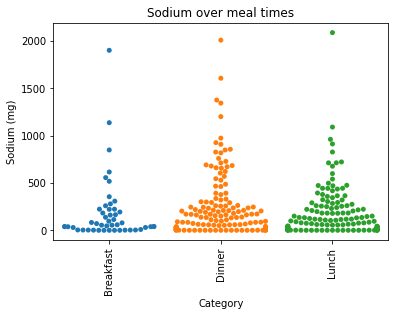

```python
import matplotlib.pyplot as plt
%matplotlib inline
import seaborn as sns

plot = sns.swarmplot(x='Category',y='Sodium (mg)', data=df)
plot.set_xticklabels(plot.get_xticklabels(),rotation = 90)
plt.title('Sodium over meal times')
plt.show()
```

```python
df['Sodium (mg)'].describe()
```

```
count     328.000000
mean      220.696646
std       317.865276
min         0.000000
25%        20.125000
50%       104.800000
75%       260.675000
max      2086.100000
Name: Sodium (mg), dtype: float64
```

```python
df.nlargest(10, 'Sodium (mg)')
```

|  | Category | Serving Size | Calories (kcal) | Protein (g) | Total Fats (g) | Saturated Fat (g) | Trans Fat (g) | Total Carbs (g) | Total Sugars (g) | Dietary Fiber (g) | Sodium (mg) | Cholesterol (mg) |
| --- | --- | --- | --- | --- | --- | --- | --- | --- | --- | --- | --- | --- |
| Buffalo Chicken, Grilled Onion, Tomato &amp; Provolone Sandwich | Lunch | 1 ea | 700.7 | 44.3 | 26.6 | 9.2 | 0.0 | 70.8 | 8.8 | 3.7 | 2086.1 | 72.9 |
| Grilled Chicken Parmesan Sandwich | Dinner | 1 each | 545.0 | 37.5 | 17.8 | 6.2 | 0.0 | 61.5 | 7.7 | 2.8 | 2006.4 | 76.2 |
| Cheese Sausage Breakfast Bagel Sandwich | Breakfast | 1 each | 1104.7 | 21.6 | 54.1 | 17.5 | 0.2 | 135.8 | 16.9 | 14.4 | 1899.5 | 45.3 |
| Chicken Noodle Soup | Dinner | 6 oz | 200.6 | 10.8 | 0.0 | 1.5 | 0.0 | 27.8 | 7.7 | 3.1 | 1604.6 | 46.3 |
| Vegan Spicy Tomato Sauce | Dinner | 3 oz | 99.0 | 2.8 | 4.0 | 0.3 | 0.0 | 14.5 | 8.5 | 3.1 | 1374.6 | 0.0 |
| Waffle | Dinner | 7 oz | 784.9 | 16.1 | 47.9 | 26.8 | 0.0 | 71.9 | 8.9 | 0.0 | 1342.3 | 392.8 |
| BFree Multigrain Wraps (purple) | Dinner | 1 each | 600.0 | 12.0 | 9.0 | 0.0 | 0.0 | 96.0 | 0.0 | 36.0 | 1200.0 | 0.0 |
| Lite Soy Sauce | Breakfast | 1 oz | 19.8 | 2.0 | 0.0 | 0.0 | 0.0 | 2.0 | 0.0 | 0.0 | 1135.6 | 0.0 |
| Marinara Sauce | Lunch | 2 oz | 77.5 | 2.1 | 3.1 | 0.2 | 0.0 | 11.4 | 6.7 | 2.5 | 1089.5 | 0.0 |
| Italian Sausage Pizza | Dinner | 1 slice | 291.3 | 17.8 | 18.7 | 7.4 | 0.0 | 18.1 | 2.7 | 1.9 | 972.7 | 41.5 |

> From above, we can see that there's a slightly large concentration of high sodium foods offered at dinner.

> We can also conclude that carby foods, such as waffles, sandwiches, or pizza, are to be avoided if you look to reduce your sodium intake.

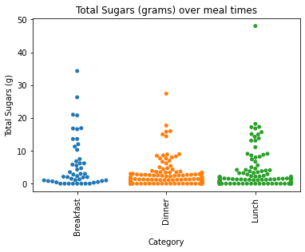

```python
plot = sns.swarmplot(x='Category',y='Total Sugars (g)', data=df)
plot.set_xticklabels(plot.get_xticklabels(),rotation = 90)
plt.title('Total Sugars (grams) over meal times')
plt.show()
```

```python
df.nlargest(10, 'Total Sugars (g)')
```

[output not shown]

> This time, we can see that lunch and breakfast has the more sugary foods!

> We can also see some surprising results by looking at the 10 most sugary foods offered. Obviously you should avoid donuts, but foods that you would think would be healthy, such as 'General tso's Tempura Cauliflower,' or 'Vegan Mango Muffins' are actually very high in sugar content!

> But, enough of what we shouldn't eat. What are some foods we should include in our diet?

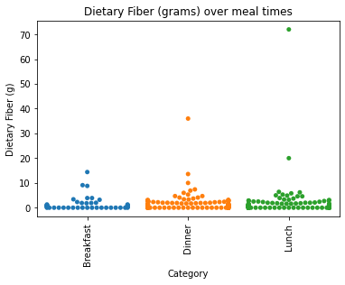

```python
plot = sns.swarmplot(x='Category',y='Dietary Fiber (g)', data=df)
plot.set_xticklabels(plot.get_xticklabels(),rotation = 90)
plt.title('Dietary Fiber (grams) over meal times')
plt.show()
```

```python
df.nlargest(10, 'Dietary Fiber (g)')
```

|  | Category | Serving Size | Calories (kcal) | Protein (g) | Total Fats (g) | Saturated Fat (g) | Trans Fat (g) | Total Carbs (g) | Total Sugars (g) | Dietary Fiber (g) | Sodium (mg) | Cholesterol (mg) |
| --- | --- | --- | --- | --- | --- | --- | --- | --- | --- | --- | --- | --- |
| BFree Sweet Potato Wraps (purple) | Lunch | 1 each | 1200.1 | 24.0 | 12.0 | 0.0 | 0.0 | 168.0 | 48.0 | 72.0 | 0.0 | 0.0 |
| BFree Multigrain Wraps (purple) | Dinner | 1 each | 600.0 | 12.0 | 9.0 | 0.0 | 0.0 | 96.0 | 0.0 | 36.0 | 1200.0 | 0.0 |
| BFree Wholegrain Pita Bread (purple) | Lunch | 1 each | 480.0 | 12.0 | 4.0 | 2.0 | 0.0 | 96.0 | 8.0 | 20.0 | 960.0 | 0.0 |
| Cheese Sausage Breakfast Bagel Sandwich | Breakfast | 1 each | 1104.7 | 21.6 | 54.1 | 17.5 | 0.2 | 135.8 | 16.9 | 14.4 | 1899.5 | 45.3 |
| Italian Herbed Lentils | Dinner | 3 oz | 153.5 | 11.1 | 0.6 | 0.0 | 0.0 | 26.0 | 1.2 | 13.6 | 0.9 | 0.0 |
| Lime Red Onion Lentils | Dinner | 3 oz | 117.5 | 8.2 | 0.3 | 0.0 | 0.0 | 20.5 | 1.4 | 10.0 | 57.5 | 0.0 |
| Oatmeal | Breakfast | 3 oz | 340.2 | 11.3 | 6.8 | 1.1 | 0.0 | 61.2 | 2.3 | 9.1 | 3.6 | 0.0 |
| Special K Berry | Breakfast | 5 oz | 321.9 | 5.9 | 0.0 | 0.0 | 0.0 | 79.0 | 26.3 | 8.8 | 556.0 | 0.0 |
| Lentil Squash Enchiladas Casserole | Dinner | 4 oz | 226.4 | 11.4 | 7.4 | 3.4 | 0.0 | 29.0 | 3.7 | 7.4 | 244.7 | 17.3 |
| Vegan Southwestern 3 Bean Soup | Dinner | 6 oz | 143.4 | 8.3 | 0.5 | 0.1 | 0.0 | 26.6 | 4.4 | 6.9 | 544.3 | 0.0 |

> Here, we can see that the foods lowest in calories and highest in fiber are lentils, so they are definitely a healthy option to inclide in your diet if you seek to eat more fiber.

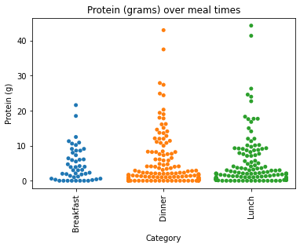

```python
plot = sns.swarmplot(x='Category',y='Protein (g)', data=df)
plot.set_xticklabels(plot.get_xticklabels(),rotation = 90)
plt.title('Protein (grams) over meal times')
plt.show()
```

```python
df.nlargest(10, 'Protein (g)')
```

[output not shown]

> Dinner seems to have a very slight advantage over lunch, and a larger advantage over breakfast in terms of protein.

> The top results here, while they may have the most protein overall, are also high in calories! If you are someone like me, who wants to maximize protein intake while minimizing the amount of calories you eat, then this may not be the most useful information.

> Let's take a look at the protein to calorie ratios then...

```python
df['Protein to Calories'] = df['Protein (g)']/df['Calories (kcal)']*100
```

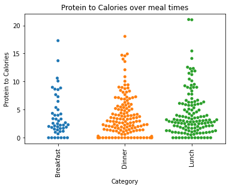

```python
plot = sns.swarmplot(x='Category',y='Protein to Calories', data=df)
plot.set_xticklabels(plot.get_xticklabels(),rotation = 90)
plt.title('Protein to Calories over meal times')
plt.show()
```

```python
df.nlargest(20, 'Protein to Calories')
```

|  | Category | Serving Size | Calories (kcal) | Protein (g) | Total Fats (g) | Saturated Fat (g) | Trans Fat (g) | Total Carbs (g) | Total Sugars (g) | Dietary Fiber (g) | Sodium (mg) | Cholesterol (mg) | Protein to Calories |
| --- | --- | --- | --- | --- | --- | --- | --- | --- | --- | --- | --- | --- | --- |
| Sliced Jalapeno Peppers | Lunch | 1 oz | 3.8 | 0.8 | 0.0 | 0.0 | 0.0 | 0.8 | 0.0 | 0.8 | 105.8 | 7.6 | 21.052632 |
| Asian Chicken Mongolian Grill | Lunch | 4 oz | 125.2 | 26.3 | 1.4 | 0.4 | 0.0 | 0.0 | 0.0 | 0.0 | 74.0 | 66.0 | 21.006390 |
| Turkey Sliced | Dinner | 3 oz | 75.9 | 13.7 | 1.5 | 0.0 | 0.0 | 1.5 | 0.0 | 0.0 | 683.4 | 30.4 | 18.050066 |
| Scrambled Egg Whites | Breakfast | 4 oz | 72.3 | 12.5 | 1.8 | 0.1 | 0.0 | 1.1 | 1.1 | 0.0 | 192.8 | 0.0 | 17.289073 |
| Lemon Oregano Chicken | Lunch | 3 oz | 113.9 | 17.6 | 4.3 | 0.5 | 0.0 | 0.0 | 0.0 | 0.0 | 357.4 | 51.4 | 15.452151 |
| Chopped Basil | Dinner | 1 oz | 6.7 | 1.0 | 0.0 | 0.0 | 0.0 | 0.7 | 0.0 | 0.3 | 1.0 | 0.0 | 14.925373 |
| Sliced Mushroom | Dinner | 1 oz | 6.8 | 1.0 | 0.0 | 0.0 | 0.0 | 1.0 | 0.0 | 0.3 | 5.1 | 0.0 | 14.705882 |
| Diced Chicken | Dinner | 2 oz | 87.8 | 12.8 | 3.4 | 1.0 | 0.0 | 2.0 | 0.7 | 0.0 | 391.5 | 37.1 | 14.578588 |
| BBQ Spiced Chicken with Caramelized Onions (purple) | Lunch | 4 oz | 129.6 | 18.3 | 4.6 | 0.9 | 0.0 | 5.2 | 1.6 | 0.6 | 197.4 | 85.1 | 14.120370 |
| Grilled Moroccan Wild Blue Catfish | Dinner | 3 oz | 115.7 | 16.2 | 5.8 | 0.2 | 0.0 | 1.8 | 0.0 | 0.2 | 110.6 | 46.8 | 14.001729 |
| Cottage Cheese | Breakfast | 2 oz | 40.1 | 5.5 | 0.5 | 0.3 | 0.0 | 3.0 | 2.0 | 0.0 | 160.6 | 5.0 | 13.715711 |
| Grilled Chicken Breast | Dinner | 1 each | 179.8 | 24.4 | 7.7 | 0.8 | 0.0 | 1.9 | 0.0 | 0.2 | 97.1 | 70.0 | 13.570634 |
| Dry Rub Wild Blue Catfish | Lunch | 4 oz | 95.5 | 12.0 | 5.4 | 0.2 | 0.0 | 2.4 | 0.0 | 0.0 | 181.1 | 34.7 | 12.565445 |
| Grilled Mushrooms | Lunch | 1 oz | 16.2 | 2.0 | 0.3 | 0.0 | 0.0 | 2.0 | 0.0 | 0.7 | 10.1 | 0.0 | 12.345679 |
| Spinach | Lunch | 2 oz | 13.0 | 1.6 | 0.2 | 0.0 | 0.0 | 2.1 | 0.2 | 1.2 | 44.8 | 0.0 | 12.307692 |
| Grilled Chicken Breast w/ Provolone | Dinner | 1 each | 230.5 | 27.9 | 11.7 | 2.9 | 0.0 | 1.9 | 0.0 | 0.2 | 218.6 | 80.1 | 12.104121 |
| Grilled Garlic Basil Chicken Alfredo (purple) | Lunch | 1 each | 206.9 | 24.6 | 9.3 | 2.5 | 0.0 | 4.4 | 0.4 | 0.1 | 540.5 | 70.0 | 11.889802 |
| Broccoli | Lunch | 1 oz | 7.6 | 0.9 | 0.0 | 0.0 | 0.0 | 1.2 | 0.3 | 0.6 | 7.6 | 0.0 | 11.842105 |
| Tofu | Lunch | 2 oz | 81.0 | 9.3 | 4.9 | 0.6 | 0.0 | 1.9 | 0.0 | 0.6 | 3.1 | 0.0 | 11.481481 |
| Collard Green with Smoked Turkey | Lunch | 4 oz | 67.6 | 7.6 | 0.2 | 0.0 | 0.0 | 10.5 | 2.2 | 2.7 | 61.2 | 14.7 | 11.242604 |

> For me, the top 20 results for the largest protein to calorie ratio was very surprising. In my meals this semester, I usually just fill up on 'Grilled Chicken Breast' until I physically can't eat it anymore. But they're only top 12 on this list! So I will definitely factor in this data for my meals next semester.

# **Conclusion**

> Well, that concludes my nutrition analysis of the food at the University of Maryland's dining halls.

> In this notebook, we went over many of the steps a data scientists goes through and used many tools we learned in class, such as web scraping, data wrangling, seaborne plots, etc.

> We have covered a lot of ground in terms of what food to be on the lookout for if you plan on improving your diet by increasing fiber and protein intake, or reducing sodium and sugars. This notebook provides a lot of useful information to healthy eaters, especially to a demographic of those who seek to maximize protein while minimizing calorie intake, i.e, a body recomposition. I plan on sharing some of these surprising results to my friends who live on-campus and have a dining plan, and hopefully this data will help them achieve their dieting goals, just as it is helping me achieve mine.